# Stat 245 – Internet Searches

Sharon Velpula

October 20, 2022

### Data

The data comes from a paper, The search engine manipulation effect (SEME) and its possible impact on the outcomes of elections by Robert Epstein and Ronald E. Robertson. They report results of experiments designed to measure the effects of biased internet search results on voter opinions.

```r
search <-
read_csv('https://sldr.netlify.app/data/election_searches.csv')

glimpse(search)
```

```
## Rows: 2,406
## Columns: 18
## $ Searches          <dbl> 2, 5, 5, 10, 15, 8, 90, 5, 20, 4, 6, 4, 5, 5, 4, 5, …
## $ Vote_Sway         <dbl> -4, -1, 1, 10, 6, -1, -1, 0, 10, 4, 3, -1, -2, 1, 8,…
## $ Pre_Vote          <dbl> 9, 2, 9, 0, 3, 2, 1, 10, 0, 2, 3, 1, 5, 9, 2, 3, 0, …
## $ Post_Vote         <dbl> 5, 1, 10, 10, 9, 1, 0, 10, 10, 6, 6, 0, 3, 10, 10, 4…
## $ Pre_Choice        <chr> "Julia Gillard", "Tony Abbott", "Julia Gillard", "To…
## $ Post_Choice       <chr> "Julia Gillard", "Tony Abbott", "Julia Gillard", "Ju…
## $ Group             <chr> "Gillard Bias", "Gillard Bias", "Gillard Bias", "Gil…
## $ Trust_Search      <chr> "Suspected bias", "Suspected bias", "Suspected bias"…
## $ Party             <chr> "Republican", "Independent", "Democrat", "Republican…
## $ Politics          <chr> "Conservative", "Moderate", "Moderate", "Conservativ…
## $ Voter_Status      <chr> "Registered voter", "Not Registered", "Registered vo…
## $ Age               <dbl> 26, 33, 44, 24, 31, 81, 61, 26, 20, 21, 20, 18, 22, …
## $ Education         <chr> "Bachelors", "Some college or associate degree", "Ad…
## $ Sex               <chr> "Male", "Male", "Female", "Male", "Female", "Female"…
## $ Race_Ethnicity    <chr> "White_NA_NA_NA_NA_NA", "NA_NA_NA_NA_NA_OtherRace", …
## $ Marital_Status    <chr> "Never married", "Divorced", "Divorced", "Never marr…
## $ Income            <chr> "$15,000 to $19,999", "$50,000 to $74,999", "$50,000…
## $ Employment_Status <chr> "Employed", "Employed", "Unemployed", "Employed", "E…
```

### Plan

I am going to fit a model to understand how the number of internet searches someone does per week relates to demographic information. I have chosen Searches as my response variable and Age, Sex, Employment Status and Education are my predictor variables. I am going to fit a negative binomial regression model because Searches, the response variable contains counts.

### Fit

```r
library(glmmTMB)
search_nb1 <- glmmTMB(Searches ~ Age + Sex + Education + Employment_Status, data = search, family = nbinom1(link = 'log'))

search_nb2 <- glmmTMB(Searches ~ Age + Sex + Education + Employment_Status, data = search, family = nbinom2(link = 'log'))

AIC(search_nb1, search_nb2)
```

```
##            df      AIC
## search_nb1 11 17699.90
## search_nb2 11 17680.89
```

## Mean-Var Relationship

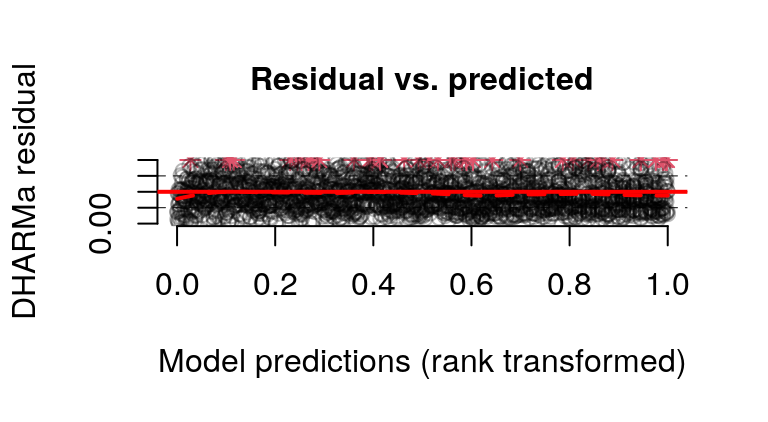

```r
library(DHARMa)
nb1_sim <- simulateResiduals(search_nb1)
plotResiduals(nb1_sim)
```

We can see here that the distribution is quite uniform and there is enough of a random spread. I think it is safe to say that this model passes the mean-variance relationship condition because the residuals are uniformly distributed.

## Independence of Residuals

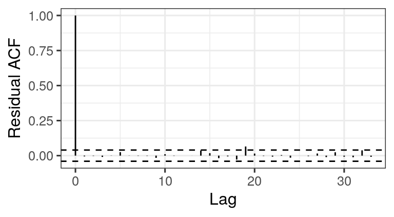

```r
s245::gf_acf(~(search_nb1))
```

We can see that there is one lag (19) that goes past the bounds and a two more (14 & 32) that are almost past the bounds. However, we can still say that this model passes the independence of residuals condition.

### Conclusion

Our model seems to pass the independence of residuals condition and the mean-variance relationship that we expect. Therefore, we can conclude that the model might be accurate to measure how the number of internet searches is affected by demographic factors of age, sex, educationa and employment status.

## Hypothetical Dataset

```r
hyp_data <- expand.grid(Age = seq(from = 10, to = 90, by = 5), Sex = 'Male', Education = 'Some college or associate degree', Employment_Status = 'Unemployed')
```

I’ve created a hypothetical data by keeping Sex, Education and Employment Status constant and letting the Age vary.

## Make predictions on link scale

```r
search_preds <- predict(search_nb1, newdata = hyp_data, type = 'link', se.fit = TRUE)

glimpse(search_preds)
```

```
## List of 2
##  $ fit   : Named num [1:17] 2.86 2.81 2.77 2.73 2.68 ...
##   ..- attr(*, "names")= chr [1:17] "eta_predict" "eta_predict" "eta_predict" "eta_predict" ...
##  $ se.fit: Named num [1:17] 0.0515 0.0477 0.0447 0.0424 0.0411 ...
##   ..- attr(*, "names")= chr [1:17] "eta_predict" "eta_predict" "eta_predict" "eta_predict" ...
```

I have made some predictions for this model

## Compute CIs on link scale, then inverse link transform

```r
hyp_data <- hyp_data |>
mutate(pred = exp(search_preds$fit),
ci_low = exp(search_preds$fit - 1.96*search_preds$se.fit),
ci_up = exp(search_preds$fit + 1.96*search_preds$se.fit))
```

I have assigned CIs using the pred data

## Prediction Plot

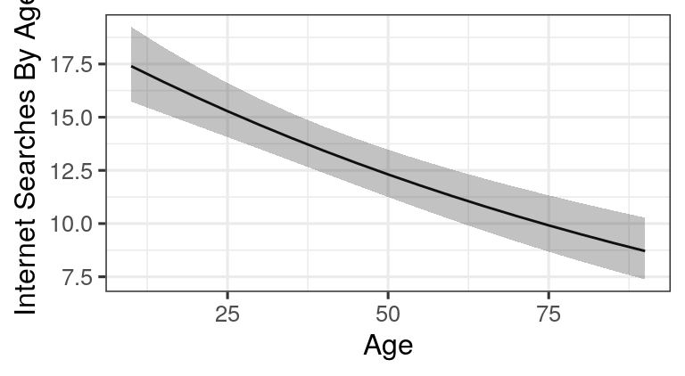

```r
gf_line(pred ~ Age, data = hyp_data) |>
  gf_ribbon(ci_low + ci_up ~ Age) |>
  gf_labs(y = 'Internet Searches By Age')
```

This prediction plot shows a negative trend and an acceptable confidence band.

## Model Selection

```r
require(MuMIn)
search_nb1 <- search_nb1 |>
  update(na.action = 'na.fail')

search_dredge <- dredge(search_nb1, rank = 'BIC')

search_dredge
```

```
## Global model call: glmmTMB(formula = Searches ~ Age + Sex + Education + Employment_Status,
##     data = search, family = nbinom1(link = "log"), ziformula = ~0,
##     dispformula = ~1, na.action = "na.fail")
## ---
## Model selection table
##    cnd((Int)) dsp((Int))  cnd(Age) cnd(Edc) cnd(Emp_Stt) cnd(Sex) df    logLik
## 6       3.011          + -0.008793                     +           4 -8854.927
## 14      2.937          + -0.008323                     +        +  6 -8850.439
## 2       2.986          + -0.009408                                 3 -8864.086
## 10      2.905          + -0.008851                              +  5 -8858.619
## 8       2.756          + -0.009124        +            +           9 -8844.177
## 4       2.686          + -0.009636        +                        8 -8848.856
## 12      2.597          + -0.009080        +                     + 10 -8842.784
## 16      2.666          + -0.008652        +            +        + 11 -8838.952
## 5       2.721          +                               +           3 -8878.923
```

[output cut: 25 more lines]